# Continuous Random Variables

A random variable $X$ is a **continuous random variable** if its possible values are not discrete (such as an interval).

Each such random variable has a function associated with it called its **probability density function** (pdf), sometimes denoted $p_X$. This function is such that $$P\{a\leq X\leq b\} = \text{area under the curve $p_X$ from $a$ to $b$}$$ for any choice of $a$ and $b$ where $a<b$.

A pdf, $p_X$, must satisfy some basic requirements:

1. $p_X(x)\geq 0$ for all real numbers $x$,
2. $p_X$ must be piecewise continuous (this means it cannot be too erratic, but it can have jumps), and
3. the area between $p_X$ and the $x$-axis must be equal to 1.

## Uniform Random Variable

A **uniform random variable** is a continuous random variable that is equal to a fixed constant whenever it is non-zero.

For example, let $X$ be associated with the pdf $$p_X(x)=\begin{cases} 1\text{ if $0\leq x\leq 1$}\\ 0\text{ otherwise}\end{cases}.$$

1. Verify that $p_X$ really is a pdf.
2. Compute $P\{1/3\leq X\leq 3/4\}$.
3. Compute $P\{X\geq 1/2\}$.
4. Compute $P\{X = 1/2\}$.
5. Compute $P\{X < 0\}$.

## Examples of Continuous Random Variables

1. Let $X$ be assocated with the pdf $$p_X(x)=\begin{cases} \frac{1}{5}\text{ if $2\leq x\leq 7$}\\ 0\text{ otherwise}\end{cases}.$$
   1. Verify that this is a pdf.
   2. Compute $P\{2.3\leq X\leq 4.4\}$.
2. Let $X$ be assocated with the pdf $$p_X(x)=\begin{cases} \frac{x}{4}\text{ if $0\leq x\leq 2$}\\ 1-\frac{x}{4}\text{ if $2\leq x\leq 4$}\\0\text{ otherwise}\end{cases}.$$
   1. Verify that this is a pdf. (Hint: Sketch the function.)
   2. Compute $P\{X\geq 2\}$.
   3. Compute $P\{X\geq 3\}$.
   4. Compute $P\{1\leq X\leq 3\}$.
   5. Compute $P\{1.5\leq X\leq 2\}$.

## More Examples

5. Suppose that the number of minutes of playing time of a certain college basketball player in a randomly chosen game has the following density function.

[figure not shown]

Find the probability that the player plays 1. Over 20 minutes 2. Less than 25 minutes 3. Between 15 and 35 minutes 4. More than 35 minutes

6. Consider the function $$f(x)=\begin{cases} c\text{ if $4\leq x\leq 20$}\\0\text{ otherwise}\end{cases}.$$ What value of $c$ makes $f(x)$ a pdf?

## A Waiting Problem

Suppose that Andrew and Kate have agreed to meet at the park. They agreed to meet at 2pm, but neither is particularly punctual or patient. They are both equally likely to show up at any time between 2pm and 3pm, and neither plans on staying at the park past 3pm. What is the probability that any one of them will have to wait more than a half an hour for the other to arrive?

# Normal Data Sets and The Empirical Rule

A dataset is said to be **normal** if a histogram describing it has the following properties:

1. It is highest at the middle interval.
2. Moving from the middle interval in either direction, the height decreases in such away that the entire histogram is bell-shaped.
3. The histogram is symmetric about its middle interval.

[figure not shown]

Normal

A dataset is said to be **approximately normal** if it appears "close" to being normal.

[figure not shown]

Approximately normal

Any data set that is not approximately symmetric about its sample median is said to be **skewed**. It is called **skewed to the right** if it has a longtail to the right and **skewed to the left** if it has a longtail to the left.

[figure not shown]

Left skewed

[figure not shown]

Right skewed

## Empirical Rule

If a dataset is approximately normal with sample mean $\overline{x}$ and sample standard deviation $s$, then

1. Approximately 68% of the observations lie within $$\overline{x}\pm s.$$
2. Approximately 95% of the observations lie within $$\overline{x}\pm 2s.$$
3. Approximately 99.7% of the observations lie within $$\overline{x}\pm 3s.$$

[figure not shown]

Empirical rule

## Empirical Rule Examples

[The Galton Board](https://www.youtube.com/watch?v=EvHiee7gs9Y)

## Coin Flips

Suppose that an experiment consists of flipping 30 fair coins and counting the number of heads that appear. We repeat this experiment 1000 times and draw a histogram of our results

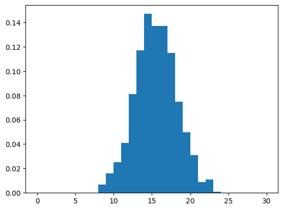

```python
import numpy as np
import matplotlib.pyplot as plt

data = np.array([np.random.randint(0,2,size=30).sum() for i in range(1000)])
plt.hist(data, bins=range(31), density=True)
plt.show()
```

```python
x_bar = data.mean()
x_bar
```

```
np.float64(15.028)
```

```python
s = data.std()
s
```

```
np.float64(2.705035304760365)
```

```python
((data < x_bar + s).sum() - (data < x_bar - s).sum())/1000
```

```
np.float64(0.653)
```

```python
((data < x_bar + 2*s).sum() - (data < x_bar - 2*s).sum())/1000
```

```
np.float64(0.956)
```

```python
((data < x_bar + 3*s).sum() - (data < x_bar - 3*s).sum())/1000
```

```
np.float64(1.0)
```